# Assignment 2: Spatial Analysis and Visualization

Healthcare Access and Equity in Pennsylvania

Author

Zicheng Xiang

Published

October 13, 2025

## Part 1: Healthcare Access for Vulnerable Populations

#### Step 1: Data Collection (5 points)

**Your Task:**

```r
#  - Step 1: Packages & global params  -
required_pkgs <- c(
  "tidyverse","sf","tigris","tidycensus","units","nngeo",
  "ggplot2","scales","janitor","glue","patchwork","osmdata"
)
for (p in required_pkgs) {
  if (!requireNamespace(p, quietly = TRUE)) install.packages(p)
  library(p, character.only = TRUE)
}
options(tigris_use_cache = TRUE, tigris_class = "sf")

#  - define BEFORE any use  -
state_abbr <- "PA"
state_name <- "Pennsylvania"
year_acs   <- 2022
survey     <- "acs5"


# tidycensus::census_api_key("YOUR_KEY_HERE", install = TRUE, overwrite = TRUE)

#  - geometries (use EPSG:5070 for distance in meters)  -
counties <- tigris::counties(state = state_abbr, cb = TRUE, year = 2022) |>
  sf::st_as_sf() |> sf::st_transform(5070)

tracts <- tigris::tracts(state = state_abbr, year = 2022, cb = TRUE) |>
  sf::st_as_sf() |> sf::st_transform(5070)

#  - hospitals from OSM within PA bbox  -
pa_bbox <- sf::st_transform(counties, 4326) |> sf::st_bbox()
q <- opq(bbox = c(pa_bbox["xmin"], pa_bbox["ymin"], pa_bbox["xmax"], pa_bbox["ymax"])) |>
  add_osm_feature(key = "amenity", value = "hospital")
osm_h <- osmdata_sf(q)

hospitals <- osm_h$osm_points |>
  sf::st_transform(5070) |>
  sf::st_intersection(sf::st_union(counties)) |>
  dplyr::mutate(name = dplyr::coalesce(name, "Unknown hospital")) |>
  dplyr::distinct(geometry, .keep_all = TRUE)


#  - quick checks / answers scaffolding  -
cat("Loaded packages:\n"); print(search())
```

```
Loaded packages:
```

```
 [1] ".GlobalEnv"         "package:osmdata"    "package:patchwork"
 [4] "package:glue"       "package:janitor"    "package:scales"
 [7] "package:nngeo"      "package:units"      "package:tidycensus"
[10] "package:tigris"     "package:sf"         "package:lubridate"
[13] "package:forcats"    "package:stringr"    "package:dplyr"
[16] "package:purrr"      "package:readr"      "package:tidyr"
[19] "package:tibble"     "package:ggplot2"    "package:tidyverse"
[22] "package:stats"      "package:graphics"   "package:grDevices"
[25] "package:utils"      "package:datasets"   "package:methods"
[28] "Autoloads"          "package:base"
```

```r
cat("\nTigris options:\n"); print(options()$tigris_use_cache); print(options()$tigris_class)
```

```
Tigris options:
```

```
[1] TRUE
```

```
[1] "sf"
```

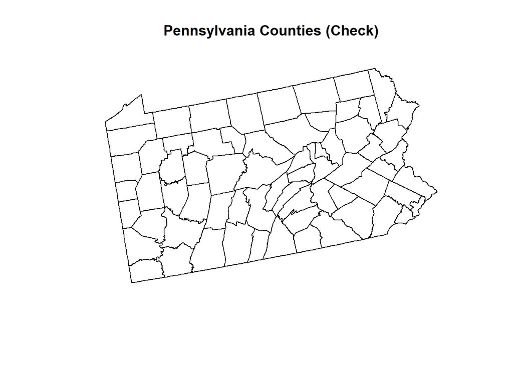

```r
#cat("\nPreview counties geom types:\n")
#print(counties |> sf::st_geometry_type() |> table())

plot(sf::st_geometry(counties), main = "Pennsylvania Counties (Check)")
```

```r
# counts
n_hosp   <- nrow(hospitals)
n_tracts <- nrow(tracts)

# CRS report
crs_counties <- sf::st_crs(counties)$input
crs_tracts   <- sf::st_crs(tracts)$input
crs_hosp     <- sf::st_crs(hospitals)$input

glue::glue("
Step 1 — Answers
- Hospitals in dataset: {n_hosp}
- Census tracts: {n_tracts}
- CRS (counties): {crs_counties}
- CRS (tracts):   {crs_tracts}
- CRS (hospitals): {crs_hosp}
") |> cat()
```

```
Step 1 — Answers
- Hospitals in dataset: 5645
- Census tracts: 3445
- CRS (counties): EPSG:5070
- CRS (tracts):   EPSG:5070
- CRS (hospitals): EPSG:5070
```

#### Step 2: Get Demographic Data

Use `tidycensus` to download tract-level demographic data for Pennsylvania.

**Your Task:**

```r
# Get demographic data from ACS
vars <- c(
  median_income = "B19013_001",
  pop_total     = "B01003_001",
  # 65+
  male_65_66    = "B01001_020",
  male_67_69    = "B01001_021",
  female_65_66  = "B01001_044",
  female_67_69  = "B01001_045",
  # poverty
  pov_universe  = "B17001_001",
  pov_below     = "B17001_002",
  # no vehicle (owner & renter occupied HHs)
  nov_owner     = "B25044_003",
  nov_renter    = "B25044_010"
)

#
tract_acs <- get_acs(
  geography = "tract",
  state = state_abbr,
  variables = vars,
  year = year_acs,
  survey = survey,
  geometry = FALSE,
  cache_table = TRUE,
  output = "wide"
)



# Join to tract boundaries
#
tract_attr <- tract_acs %>%
  dplyr::transmute(
    GEOID,
    median_income = median_incomeE,
    pop_total     = pop_totalE,
    age65         = male_65_66E + male_67_69E + female_65_66E + female_67_69E,
    pov_rate      = ifelse(pov_universeE > 0, pov_belowE / pov_universeE, NA_real_),
    nov_hh        = nov_ownerE + nov_renterE
  )

#
tracts_attr <- tracts %>%
  dplyr::left_join(tract_attr, by = "GEOID")

#  - Step 2 answers  -
sum(is.na(tracts_attr$median_income))
```

```
[1] 62
```

```r
median(tracts_attr$median_income, na.rm = TRUE)
```

```
[1] 70188
```

**Questions to answer:** - What year of ACS data are you using? 2022 (5-Year Estimates) - How many tracts have missing income data? 62 - What is the median income across all PA census tracts? 70188

#### Step 3: Define Vulnerable Populations

**Your Task:**

```r
# Filter for vulnerable tracts based on your criteria
tracts_attr <- tracts_attr %>%
  mutate(
    share65       = ifelse(pop_total > 0, age65 / pop_total, NA_real_),
    nov_percapita = ifelse(pop_total > 0, nov_hh / pop_total, NA_real_),
    inc_rev       = -median_income,             # reverse: lower income => higher vulnerability
    z_income      = scale(inc_rev)[,1],
    z_poverty     = scale(pov_rate)[,1],
    z_65          = scale(share65)[,1],
    z_noveh       = scale(nov_percapita)[,1],
    vuln_index    = rowMeans(cbind(z_income, z_poverty, z_65, z_noveh), na.rm = TRUE)
  )

sum(tracts_attr$median_income < 70000 & tracts_attr$share65 > 0.20, na.rm = TRUE)
```

```
[1] 2
```

#### Step 4: Calculate Distance to Hospitals

**Your Task:**

```r
# Transform to appropriate projected CRS

pa_bbox <- st_transform(counties, 4326) %>% st_bbox()

q <- opq(bbox = c(pa_bbox["xmin"], pa_bbox["ymin"], pa_bbox["xmax"], pa_bbox["ymax"])) %>%
  add_osm_feature(key = "amenity", value = "hospital")

osm_h <- osmdata_sf(q)

hospitals <- osm_h$osm_points %>%
  st_transform(5070) %>%
  st_intersection(st_union(counties)) %>%
  mutate(name = coalesce(name, "Unknown hospital")) %>%
  distinct(geometry, .keep_all = TRUE)

glue("Hospitals found (points): {nrow(hospitals)}")
```

```
Hospitals found (points): 5645
```

```r
# Calculate distance from each tract centroid to nearest hospital
# Centroids (use within for compact tracts; for complex shapes you may consider population-weighted centroids)
tract_cent <- st_point_on_surface(tracts_attr)

# Nearest neighbor (index + distance)
nn <- nngeo::st_nn(tract_cent, hospitals, k = 1, returnDist = TRUE)

# Distances are in meters because EPSG:5070 is projected in meters
dist_m <- sapply(nn$dist, function(x) ifelse(length(x)==0, NA_real_, x[1]))

tracts_attr <- tracts_attr %>%
  mutate(
    dist_hosp_m = dist_m,
    dist_hosp_km = set_units(dist_hosp_m, "m") %>% set_units("km") %>% drop_units()
  )
summary(tracts_attr$dist_hosp_km)
```

```
     Min.   1st Qu.    Median      Mean   3rd Qu.      Max.
 0.008897  1.606437  3.458952  5.927223  8.169082 51.890854
```

```r
sum(tracts_attr$dist_hosp_km > 24.1, na.rm = TRUE)
```

```
[1] 69
```

#### Step 5: Identify Underserved Areas

**Your Task:**

```r
# Create underserved variable

#   thresholds (data-driven; adjust if you prefer fixed cutoffs)
income_threshold   <- quantile(tracts_attr$median_income, 0.25, na.rm = TRUE)  # bottom 25% income
elderly_threshold  <- quantile(tracts_attr$share65,       0.75, na.rm = TRUE)  # top 25% 65+ share
fifteen_miles_km   <- units::set_units(15, "mi") |> units::set_units("km") |> units::drop_units()

#   flags: vulnerable & underserved
tracts_attr <- tracts_attr %>%
  mutate(
    vulnerable  = (median_income < income_threshold) & (share65 > elderly_threshold),
    underserved = vulnerable & (dist_hosp_km > fifteen_miles_km)
  )

# (optional) quick summary
glue::glue("
Vulnerable tracts: {sum(tracts_attr$vulnerable,  na.rm = TRUE)}
Underserved tracts (>15 miles): {sum(tracts_attr$underserved, na.rm = TRUE)}
Share underserved: {round(100 * mean(tracts_attr$underserved, na.rm = TRUE), 1)}%
") |> print()
```

```
Vulnerable tracts: 150
Underserved tracts (>15 miles): 7
Share underserved: 0.2%
```

#### Step 6: Aggregate to County Level

**Your Task:**

```r
# Spatial join tracts to counties
safe_wmean <- function(x, w) {
  x <- as.numeric(x)
  w <- as.numeric(w)
  idx <- is.finite(x) & is.finite(w) & w > 0
  if (!any(idx)) return(NA_real_)
  stats::weighted.mean(x[idx], w[idx])
}

# CRS
counties <- sf::st_transform(counties, sf::st_crs(tracts_attr))

# county_name
cnty_keep <- counties %>%
  dplyr::select(COUNTYFP, county_name = NAME)

# tract ∈ county
tracts_in_cnty <- sf::st_join(
  tracts_attr,
  cnty_keep,
  join = sf::st_within,
  left = TRUE
)

# numeric
tracts_in_cnty_num <- tracts_in_cnty %>%
  dplyr::mutate(
    pop_total     = as.numeric(pop_total),
    median_income = as.numeric(median_income),
    pov_rate      = as.numeric(pov_rate),
    share65       = as.numeric(share65),
    nov_percapita = as.numeric(nov_percapita),
    vuln_index    = as.numeric(vuln_index),
    dist_hosp_km  = as.numeric(dist_hosp_km)
  )

# Aggregate statistics by county
safe_wmean <- function(x, w) {
  x <- as.numeric(x); w <- as.numeric(w)
  idx <- is.finite(x) & is.finite(w) & w > 0
  if (!any(idx)) return(NA_real_)
  stats::weighted.mean(x[idx], w[idx])
}

county_stats <- tracts_in_cnty_num %>%
  sf::st_drop_geometry() %>%
  dplyr::group_by(county_name) %>%
  dplyr::summarise(
    n_tracts          = dplyr::n(),

    median_income_wt  = safe_wmean(.data$median_income, .data$pop_total),
    pov_rate_wt       = safe_wmean(.data$pov_rate,      .data$pop_total),
    share65_wt        = safe_wmean(.data$share65,       .data$pop_total),
    nov_percapita_wt  = safe_wmean(.data$nov_percapita, .data$pop_total),
    vuln_index_wt     = safe_wmean(.data$vuln_index,    .data$pop_total),

    pop_total_sum     = sum(.data$pop_total, na.rm = TRUE),

    min_dist_hosp_km  = suppressWarnings(min(.data$dist_hosp_km, na.rm = TRUE)),
    .groups = "drop"
  )

#
county_map <- counties %>%
  dplyr::left_join(county_stats, by = c("NAME" = "county_name"))

#  - Step 6 answers  -

county_underserved <- tracts_in_cnty_num %>%
  sf::st_drop_geometry() %>%
  group_by(county_name) %>%
  summarise(
    n_tracts = n(),
    n_vulnerable = sum(vulnerable, na.rm = TRUE),
    n_underserved = sum(underserved, na.rm = TRUE),
    pct_underserved = 100 * n_underserved / n_tracts,
    vulnerable_pop_far = sum(pop_total[vulnerable & dist_hosp_km > 24.14], na.rm = TRUE) # >15 miles
  ) %>%
  arrange(desc(pct_underserved))

# Top 5 counties by % underserved vulnerable tracts
top5_pct <- county_underserved %>%
  arrange(desc(pct_underserved)) %>%
  slice_head(n = 5) %>%
  select(County = county_name,
         `Underserved Tracts (%)` = pct_underserved,
         `Vulnerable Tracts` = n_vulnerable,
         `Underserved Tracts` = n_underserved)

#  Top 5 counties by total vulnerable people far from hospitals
top5_pop <- county_underserved %>%
  arrange(desc(vulnerable_pop_far)) %>%
  slice_head(n = 5) %>%
  select(County = county_name,
         `Vulnerable Pop >15mi` = vulnerable_pop_far,
         `Underserved Tracts` = n_underserved,
         `Pct Underserved (%)` = pct_underserved)


glue::glue("Top 5 counties by percentage of underserved vulnerable tracts:") |> print()
```

```
Top 5 counties by percentage of underserved vulnerable tracts:
```

```r
top5_pct %>% knitr::kable(digits = 1, caption = "Counties with Highest % of Underserved Vulnerable Tracts")
```

Counties with Highest % of Underserved Vulnerable Tracts

| County | Underserved Tracts (%) | Vulnerable Tracts | Underserved Tracts |
| --- | --- | --- | --- |
| Forest | 50.0 | 1 | 1 |
| Sullivan | 25.0 | 1 | 1 |
| Juniata | 16.7 | 1 | 1 |
| Potter | 14.3 | 2 | 1 |
| Wayne | 5.9 | 1 | 1 |

```r
glue::glue("Top 5 counties by total vulnerable people living >15 miles from hospitals:") |> print()
```

```
Top 5 counties by total vulnerable people living >15 miles from hospitals:
```

```r
top5_pop %>% knitr::kable(digits = 0, caption = "Counties with Most Vulnerable People Far from Hospitals")
```

Counties with Most Vulnerable People Far from Hospitals

| County | Vulnerable Pop >15mi | Underserved Tracts | Pct Underserved (%) |
| --- | --- | --- | --- |
| Dauphin | 4018 | 1 | 1 |
| Forest | 2701 | 1 | 50 |
| Crawford | 2536 | 1 | 4 |
| Potter | 1948 | 1 | 14 |
| Wayne | 1923 | 1 | 6 |

**Questions to answer:** - Which 5 counties have the highest percentage of underserved vulnerable tracts? Forest,Sullivan,Juniata,Potter,Wayne - Which counties have the most vulnerable people living far from hospitals? Dauphin - Are there any patterns in where underserved counties are located? No, this pattern is not surprising.The underserved counties are predominantly located in northern and central Pennsylvania, which are mountainous, sparsely populated, and rural.

#### Step 7: Create Summary Table

**Your Task:**

```r
# Create and format priority counties table
#   county-level vulnerable metrics (meets the "Required county-level statistics")
county_vuln_metrics <- tracts_in_cnty_num %>%
  sf::st_drop_geometry() %>%
  dplyr::group_by(county_name) %>%
  dplyr::summarise(
    vuln_tracts            = sum(vulnerable, na.rm = TRUE),
    underserved_tracts     = sum(underserved, na.rm = TRUE),
    pct_underserved_vuln   = dplyr::if_else(vuln_tracts > 0,
                                            100 * underserved_tracts / vuln_tracts,
                                            NA_real_),
    vuln_pop_total         = sum(pop_total[vulnerable], na.rm = TRUE),
    vuln_pop_far           = sum(pop_total[vulnerable & dist_hosp_km > 24.14], na.rm = TRUE), # >15 mi
    avg_dist_vuln_km       = mean(dist_hosp_km[vulnerable], na.rm = TRUE),
    .groups = "drop"
  )

#   join with existing county-level stats to get county population & min distance
county_vuln_metrics <- county_vuln_metrics %>%
  dplyr::left_join(
    county_stats %>%
      dplyr::select(county_name, pop_total_sum, min_dist_hosp_km),
    by = "county_name"
  )

#   priority score (you can tweak weights if needed)
# Higher % underserved (among vulnerable), more vulnerable pop far from hospitals, and longer avg distance => higher priority
county_priority <- county_vuln_metrics %>%
  dplyr::mutate(
    # Normalize components to [0,1] for a composite index
    z_pct    = scales::rescale(pct_underserved_vuln, to = c(0, 1), from = range(pct_underserved_vuln, na.rm = TRUE)),
    z_popfar = scales::rescale(vuln_pop_far,        to = c(0, 1), from = range(vuln_pop_far,        na.rm = TRUE)),
    z_dist   = scales::rescale(avg_dist_vuln_km,    to = c(0, 1), from = range(avg_dist_vuln_km,    na.rm = TRUE)),
    priority_score = 0.45 * z_pct + 0.35 * z_popfar + 0.20 * z_dist
  ) %>%
  dplyr::arrange(dplyr::desc(priority_score)) %>%
  dplyr::slice_head(n = 10)

#   pretty formatting for table output
priority_table <- county_priority %>%
  dplyr::transmute(
    County                        = county_name,
    `Vulnerable Tracts`           = vuln_tracts,
    `Underserved Tracts`          = underserved_tracts,
    `% Underserved (of Vulnerable)` = scales::number(pct_underserved_vuln, accuracy = 0.1),
    `Avg Distance (mi, Vulnerable)` = scales::number(avg_dist_vuln_km * 0.621371, accuracy = 0.1),
    `Vulnerable Pop (total)`      = scales::comma(vuln_pop_total),
    `Vulnerable Pop >15 mi`       = scales::comma(vuln_pop_far),
    `County Pop (total)`          = scales::comma(pop_total_sum),
    `Priority Score`              = scales::number(priority_score, accuracy = 0.001)
  )

#   render professional table
knitr::kable(
  priority_table,
  caption = "Top 10 Priority Counties for Healthcare Investment in Pennsylvania (Composite of % underserved among vulnerable tracts, vulnerable population >15 miles from hospitals, and average distance for vulnerable tracts)."
)
```

Top 10 Priority Counties for Healthcare Investment in Pennsylvania (Composite of % underserved among vulnerable tracts, vulnerable population >15 miles from hospitals, and average distance for vulnerable tracts).

| County | Vulnerable Tracts | Underserved Tracts | % Underserved (of Vulnerable) | Avg Distance (mi, Vulnerable) | Vulnerable Pop (total) | Vulnerable Pop >15 mi | County Pop (total) | Priority Score |
| --- | --- | --- | --- | --- | --- | --- | --- | --- |
| Dauphin | 1 | 1 | 100.0 | 19.2 | 4,018 | 4,018 | 286,108 | 0.981 |
| Forest | 1 | 1 | 100.0 | 18.3 | 2,701 | 2,701 | 6,959 | 0.858 |
| Wayne | 1 | 1 | 100.0 | 15.8 | 1,923 | 1,923 | 51,227 | 0.766 |
| Juniata | 1 | 1 | 100.0 | 16.4 | 1,782 | 1,782 | 23,535 | 0.759 |
| Sullivan | 1 | 1 | 100.0 | 21.2 | 918 | 918 | 5,880 | 0.730 |
| Crawford | 3 | 1 | 33.3 | 10.6 | 6,684 | 2,536 | 83,876 | 0.471 |
| Potter | 2 | 1 | 50.0 | 8.0 | 6,205 | 1,948 | 16,390 | 0.469 |
| Huntingdon | 1 | 0 | 0.0 | 13.9 | 2,558 | 0 | 44,123 | 0.131 |
| Warren | 1 | 0 | 0.0 | 13.8 | 1,705 | 0 | 38,492 | 0.130 |
| McKean | 1 | 0 | 0.0 | 10.9 | 1,843 | 0 | 40,459 | 0.103 |

## Part 2: Comprehensive Visualization

### Map 1: County-Level Choropleth

**Your Task:**

[figure not shown]

```r
# Create county-level access map
# 1) Prepare county-level choropleth data: % of vulnerable tracts that are underserved
county_choro <- counties %>%
  dplyr::left_join(
    county_underserved %>%
      dplyr::select(county_name, pct_underserved, n_vulnerable, n_underserved),
    by = c("NAME" = "county_name")
  )

# 2) Ensure hospitals are in the same CRS as counties
hospitals_plot <- hospitals %>% sf::st_transform(sf::st_crs(counties))

# 3) Map
ggplot() +
  geom_sf(
    data = county_choro,
    aes(fill = pct_underserved),
    color = "white", linewidth = 0.25
  ) +
  geom_sf(
    data = hospitals_plot,
    color = "black", alpha = 0.5, size = 0.6
  ) +
  coord_sf() +
  scale_fill_viridis_c(
    option = "magma",
    na.value = "grey90",
    labels = scales::label_percent(accuracy = 1, scale = 1),
    name = "% Underserved among Vulnerable Tracts"
  ) +
  labs(
    title = "Healthcare Access Challenges in Pennsylvania (County Level)",
    subtitle = "Percent of vulnerable census tracts located >15 miles from the nearest hospital; dots show hospital locations",
    caption = "Sources: TIGER/Line (tigris), ACS 5-year (tidycensus), OpenStreetMap (osmdata). Projection: EPSG:5070 (meters)."
  ) +
  theme_void(base_size = 12) +
  theme(
    legend.position = "right",
    legend.title = element_text(face = "bold"),
    plot.title = element_text(face = "bold"),
    plot.caption = element_text(color = "grey30")
  )
```

### Map 2: Detailed Vulnerability Map

Create a map highlighting underserved vulnerable tracts.

**Your Task:**

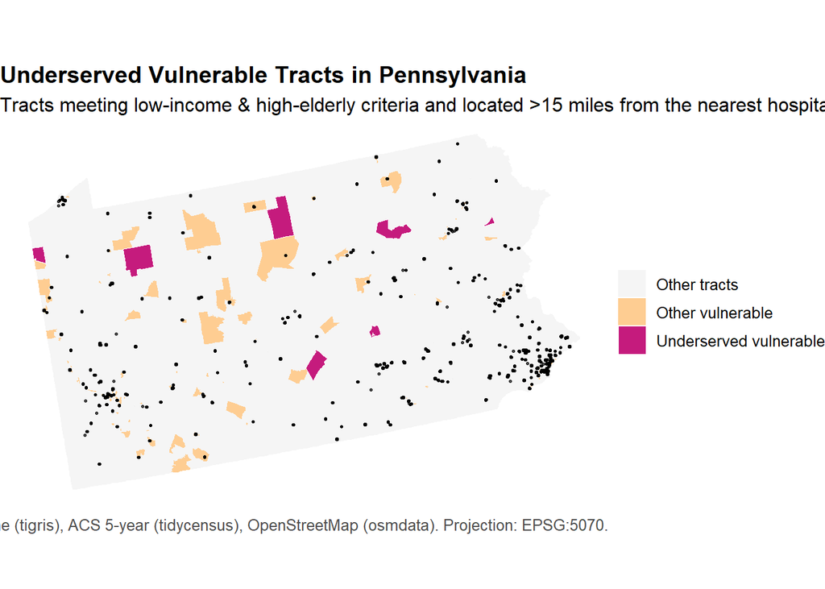

```r
# Create detailed tract-level map
# Ensure common CRS
crs_use <- sf::st_crs(counties)
tracts_plot    <- tracts_attr %>% sf::st_transform(crs_use)
counties_plot  <- counties    %>% sf::st_transform(crs_use)
hospitals_plot <- hospitals   %>% sf::st_transform(crs_use)

# Class for visual hierarchy
tracts_plot <- tracts_plot %>%
  dplyr::mutate(
    vuln_class = dplyr::case_when(
      underserved ~ "Underserved vulnerable",
      vulnerable  ~ "Other vulnerable",
      TRUE        ~ "Other tracts"
    ),
    vuln_class = factor(vuln_class,
                        levels = c("Underserved vulnerable","Other vulnerable","Other tracts"))
  )

ggplot() +
  # base: all tracts (very light)
  geom_sf(data = tracts_plot %>% dplyr::filter(vuln_class == "Other tracts"),
          aes(fill = vuln_class), color = NA, alpha = 0.4) +
  # vulnerable but not underserved (mid emphasis)
  geom_sf(data = tracts_plot %>% dplyr::filter(vuln_class == "Other vulnerable"),
          aes(fill = vuln_class), color = NA, alpha = 0.7) +
  # highlight: underserved vulnerable (strong emphasis)
  geom_sf(data = tracts_plot %>% dplyr::filter(vuln_class == "Underserved vulnerable"),
          aes(fill = vuln_class), color = "white", linewidth = 0.1) +
  # county outlines for context
  geom_sf(data = sf::st_union(counties_plot), fill = NA, color = "white", linewidth = 0.4) +
  # hospitals as points
  geom_sf(data = hospitals_plot, color = "black", alpha = 0.7, size = 0.6) +
  coord_sf() +
  scale_fill_manual(
    name = NULL,
    values = c("Underserved vulnerable" = "#C51B7D",   # magenta/red -> strongest contrast
               "Other vulnerable"       = "#FDB863",   # amber
               "Other tracts"           = "#E6E6E6")   # light gray
  ) +
  labs(
    title = "Underserved Vulnerable Tracts in Pennsylvania",
    subtitle = "Tracts meeting low-income & high-elderly criteria and located >15 miles from the nearest hospital",
    caption = "Sources: TIGER/Line (tigris), ACS 5-year (tidycensus), OpenStreetMap (osmdata). Projection: EPSG:5070."
  ) +
  theme_void(base_size = 12) +
  theme(
    legend.position = "right",
    plot.title = element_text(face = "bold"),
    plot.caption = element_text(color = "grey30")
  )
```